# Regresion_Class_07_Nov_2023_Modelos_Lineales

Sergibar

2023-11-07

# Aplicación de modelos lineales

## Panel Princeton Data

```r
citation('foreign')
```

```
##
##
##   R Core Team (2022). _foreign: Read Data Stored by 'Minitab', 'S',
##   'SAS', 'SPSS', 'Stata', 'Systat', 'Weka', 'dBase', ..._. R package
##   version 0.8-83, <https://CRAN.R-project.org/package=foreign>.
##
## A BibTeX entry for LaTeX users is
##
##   @Manual{,
##     title = {foreign: Read Data Stored by 'Minitab', 'S', 'SAS', 'SPSS', 'Stata',
## 'Systat', 'Weka', 'dBase', ...},
##     author = {{R Core Team}},
##     year = {2022},
##     note = {R package version 0.8-83},
##     url = {https://CRAN.R-project.org/package=foreign},
##   }
```

### Se lee la data en el objeto Panel

```r
library(foreign)
Panel <- read.dta("http://dss.princeton.edu/training/Panel101.dta")
head(Panel)
```

```
##   country year           y y_bin        x1         x2          x3   opinion op
## 1       A 1990  1342787840     1 0.2779036 -1.1079559  0.28255358 Str agree  1
## 2       A 1991 -1899660544     0 0.3206847 -0.9487200  0.49253848     Disag  0
## 3       A 1992   -11234363     0 0.3634657 -0.7894840  0.70252335     Disag  0
## 4       A 1993  2645775360     1 0.2461440 -0.8855330 -0.09439092     Disag  0
## 5       A 1994  3008334848     1 0.4246230 -0.7297683  0.94613063     Disag  0
## 6       A 1995  3229574144     1 0.4772141 -0.7232460  1.02968037 Str agree  1
```

```r
typeof(Panel)
```

```
## [1] "list"
```

### Para presentar mejor la data

```r
knitr::kable(Panel)
```

| country | year | y | y_bin | x1 | x2 | x3 | opinion | op |
| --- | --- | --- | --- | --- | --- | --- | --- | --- |
| A | 1990 | 1342787840 | 1 | 0.2779036 | -1.1079559 | 0.2825536 | Str agree | 1 |
| A | 1991 | -1899660544 | 0 | 0.3206847 | -0.9487200 | 0.4925385 | Disag | 0 |
| A | 1992 | -11234363 | 0 | 0.3634657 | -0.7894840 | 0.7025234 | Disag | 0 |
| A | 1993 | 2645775360 | 1 | 0.2461440 | -0.8855330 | -0.0943909 | Disag | 0 |
| A | 1994 | 3008334848 | 1 | 0.4246230 | -0.7297683 | 0.9461306 | Disag | 0 |
| A | 1995 | 3229574144 | 1 | 0.4772141 | -0.7232460 | 1.0296804 | Str agree | 1 |
| A | 1996 | 2756754176 | 1 | 0.4998050 | -0.7815716 | 1.0922881 | Disag | 0 |
| A | 1997 | 2771810560 | 1 | 0.0516284 | -0.7048455 | 1.4159008 | Str agree | 1 |
| A | 1998 | 3397338880 | 1 | 0.3664108 | -0.6983712 | 1.5487227 | Disag | 0 |
| A | 1999 | 39770336 | 1 | 0.3958425 | -0.6431540 | 1.7941980 | Str disag | 0 |
| B | 1990 | -5934699520 | 0 | -0.0818500 | 1.4251202 | 0.0234281 | Agree | 1 |
| B | 1991 | -711623744 | 0 | 0.1061600 | 1.6496018 | 0.2603625 | Str agree | 1 |
| B | 1992 | -1933116160 | 0 | 0.3537852 | 1.5937191 | -0.2343988 | Agree | 1 |
| B | 1993 | 3072741632 | 1 | 0.7267770 | 1.6917576 | 0.2562243 | Str disag | 0 |
| B | 1994 | 3768078848 | 1 | 0.7193949 | 1.7414261 | 0.4117495 | Disag | 0 |
| B | 1995 | 2837581312 | 1 | 0.6715466 | 1.7083139 | 0.5358430 | Str disag | 0 |
| B | 1996 | 577199360 | 1 | 0.8198573 | 1.5324961 | -0.4996490 | Str agree | 1 |
| B | 1997 | 1786851584 | 1 | 0.8801672 | 1.5021962 | -0.5762677 | Disag | 0 |
| B | 1998 | -149072048 | 0 | 0.7045161 | 1.4236463 | -0.4484192 | Agree | 1 |
| B | 1999 | -1174480128 | 0 | 0.2369673 | 1.4545859 | -0.0493640 | Str disag | 0 |
| C | 1990 | -1292379264 | 0 | 1.3125607 | -1.2931356 | 0.2040830 | Agree | 1 |
| C | 1991 | -3415966464 | 0 | 1.1774836 | -1.3442180 | 0.2839719 | Str agree | 1 |
| C | 1992 | -355804672 | 0 | 1.2564080 | -1.2599510 | 0.3733927 | Agree | 1 |
| C | 1993 | 1225180032 | 1 | 1.4215446 | -1.3117452 | -0.3759656 | Disag | 0 |
| C | 1994 | 3802287616 | 1 | 1.1141931 | -1.2849948 | 0.5604675 | Str disag | 0 |
| C | 1995 | 1959696640 | 1 | 1.1594839 | -1.2188276 | 0.6954080 | Agree | 1 |
| C | 1996 | 530576672 | 1 | 1.1604543 | -1.2350063 | 0.8168938 | Agree | 1 |
| C | 1997 | 3128852224 | 1 | 1.4464116 | -1.3275964 | -0.1420691 | Str disag | 0 |
| C | 1998 | 3201045760 | 1 | 1.1516267 | -1.2061129 | 1.1945814 | Str agree | 1 |
| C | 1999 | 4663067648 | 1 | 1.1905441 | -1.1266172 | 1.6701604 | Disag | 0 |
| D | 1990 | 1883025152 | 1 | -0.3139127 | 1.7366557 | 0.6466370 | Disag | 0 |
| D | 1991 | 6037768704 | 1 | 0.3600910 | 2.1318641 | 1.0999417 | Disag | 0 |
| D | 1992 | 10244189 | 1 | 0.0518877 | 1.6816775 | 0.9697682 | Str agree | 1 |
| D | 1993 | 5067265024 | 1 | 0.2094435 | 1.6149769 | -0.2125782 | Str agree | 1 |
| D | 1994 | 3882478336 | 1 | 0.3820700 | 1.5683011 | -1.1653867 | Disag | 0 |
| D | 1995 | 8827006976 | 1 | 0.2420858 | 1.5412215 | -0.1841310 | Agree | 1 |
| D | 1996 | 5782000128 | 1 | 0.4863668 | 1.7423391 | -0.0373145 | Str disag | 0 |
| D | 1997 | 5090524160 | 1 | 0.3594260 | 1.8742865 | 0.0878680 | Str agree | 1 |
| D | 1998 | 1850565248 | 1 | 0.2322035 | 1.5953021 | 0.0724755 | Disag | 0 |
| D | 1999 | -2025476864 | 0 | -0.0799890 | 1.7047973 | 0.5584330 | Str agree | 1 |
| E | 1990 | 1342787840 | 1 | 0.4528672 | 1.7284026 | 0.5970579 | Str disag | 0 |
| E | 1991 | 2296009472 | 1 | 0.4190403 | 1.7068400 | 0.7931353 | Str agree | 1 |
| E | 1992 | 1737627776 | 1 | 0.3852135 | 1.6852775 | 0.9892128 | Agree | 1 |
| E | 1993 | 113973136 | 1 | -0.2442877 | 1.6492835 | 1.2241328 | Str agree | 1 |
| E | 1994 | 260098048 | 1 | 1.3911400 | 2.5302765 | -0.5262014 | Str disag | 0 |
| E | 1995 | -7863482880 | 0 | 0.3196856 | 1.1890552 | -0.4842537 | Agree | 1 |
| E | 1996 | 3520491520 | 1 | 0.6109768 | 1.4845277 | -0.9789551 | Agree | 1 |
| E | 1997 | 5234565120 | 1 | 0.7176149 | 1.5544620 | -0.9886366 | Str disag | 0 |
| E | 1998 | 344746176 | 1 | 0.6961383 | 1.7010406 | -0.0896525 | Disag | 0 |
| E | 1999 | 243920688 | 1 | 0.6066207 | 1.6119040 | -0.0892988 | Str disag | 0 |
| F | 1990 | 1342787840 | 1 | -0.5675749 | -0.3466710 | 1.2584193 | Str agree | 1 |
| F | 1991 | 3560401920 | 1 | 0.1597458 | -0.4641182 | 0.3266530 | Str disag | 0 |
| F | 1992 | 3192281088 | 1 | 0.8870664 | -0.5815655 | -0.6051133 | Agree | 1 |
| F | 1993 | 8941232128 | 1 | 0.5324180 | -0.7553238 | -0.5115759 | Agree | 1 |
| F | 1994 | 8124504576 | 1 | 0.8726001 | -0.7114431 | 0.2057027 | Str agree | 1 |
| F | 1995 | 491740096 | 1 | 0.9193523 | -0.3697441 | -0.0129275 | Str agree | 1 |
| F | 1996 | 3497164544 | 1 | 1.3968923 | -0.3601406 | 0.6786764 | Str agree | 1 |
| F | 1997 | 4764803072 | 1 | 0.9868861 | -0.3590902 | 0.2422617 | Str agree | 1 |
| F | 1998 | -4671723520 | 0 | 0.7883091 | -0.7556524 | 0.7334780 | Agree | 1 |
| F | 1999 | 6349319168 | 1 | 0.2793870 | -0.4601679 | 1.1731720 | Disag | 0 |
| G | 1990 | 1342787840 | 1 | 0.9448817 | -1.5150151 | 1.4526573 | Str disag | 0 |
| G | 1991 | -1518985728 | 0 | 1.0987283 | -1.4614717 | 1.4396447 | Agree | 1 |
| G | 1992 | 1912769920 | 1 | 1.2525749 | -1.4079282 | 1.4266320 | Str agree | 1 |
| G | 1993 | 1345690240 | 1 | 0.7627645 | -1.3519315 | 1.8544863 | Str disag | 0 |
| G | 1994 | 2793515008 | 1 | 1.2064556 | -1.3252175 | 2.2365303 | Str disag | 0 |
| G | 1995 | 1323696384 | 1 | 1.0871865 | -1.4098167 | 2.8298085 | Str disag | 0 |
| G | 1996 | 254524176 | 1 | 0.7810755 | -1.3279996 | 4.2782240 | Str agree | 1 |
| G | 1997 | 3297033216 | 1 | 1.2578795 | -1.5773667 | 4.5873256 | Disag | 0 |
| G | 1998 | 3011820800 | 1 | 1.2427766 | -1.6012177 | 6.1137619 | Disag | 0 |
| G | 1999 | 3296283392 | 1 | 1.2342002 | -1.6217614 | 7.1689219 | Disag | 0 |

```r
library(tidyverse)
Panel%>% select(country, year, x1)%>%group_by(country)%>%summarise(media=mean(x1))
```

```
## # A tibble: 7 × 2
##   country media
##   <fct>   <dbl>
## 1 A       0.342
## 2 B       0.514
## 3 C       1.24
## 4 D       0.193
## 5 E       0.536
## 6 F       0.626
## 7 G       1.09
```

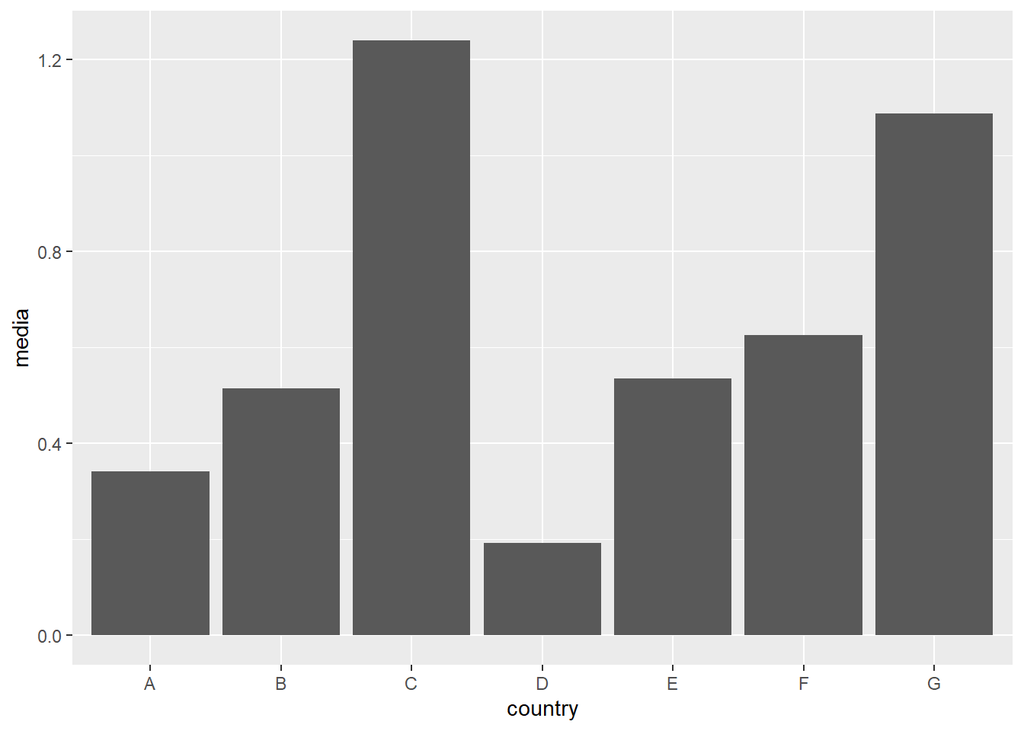

```r
library(tidyverse)

Panel%>% select(country, year, x1)%>%group_by(country)%>%summarise(media=mean(x1))%>%ggplot(aes(x=country, y=media))+geom_col()
```

# Modelo Lineal Simple

## Ejemplo 2: Precio de acción en función de tamaño de la empresa

```r
library(readxl)
df_ejemplo2_precio_acci <- read_excel("Regresion_Class_29_August_Modelo_Lineal_Simple_ejemplo2.xlsx",
                 sheet = "Sheet1")
df_ejemplo2_precio_acci
```

```
## # A tibble: 12 × 2
##    `Tamaño ($ M)` `Precio por acción`
##             <dbl>               <dbl>
##  1            9                  10.8
##  2           94.2                11.3
##  3           27.3                11.2
##  4          179.                 11.1
##  5           71.9                11.1
##  6           97.9                11.2
##  7           93.5                11
##  8           70                  10.7
##  9          161.                 11.3
## 10           96.5                10.6
## 11           83                  10.5
## 12           23.5                10.3
```

### Renombrando las columnas de Ejemplo 2: Precio de acción en función de tamaño de la empresa

```r
# Rename columns
colnames(df_ejemplo2_precio_acci) <- c("TAMANIO", "PPA")

# View new column names
colnames(df_ejemplo2_precio_acci)
```

```
## [1] "TAMANIO" "PPA"
```

```r
df_ejemplo2_precio_acci$TAMANIO
```

```
##  [1]   9.0  94.2  27.3 179.2  71.9  97.9  93.5  70.0 160.7  96.5  83.0  23.5
```

### Aplicaición de modelo lineal a Ejemplo 2: Precio de acción en función de tamaño de la empresa

```r
# Load libraries
library(stats)

# Fit linear model
lm_model_precio_acci <- lm(PPA ~ TAMANIO, data = df_ejemplo2_precio_acci)

# View model summary
summary(lm_model_precio_acci)
```

```
##
## Call:
## lm(formula = PPA ~ TAMANIO, data = df_ejemplo2_precio_acci)
##
## Residuals:
##      Min       1Q   Median       3Q      Max
## -0.44857 -0.22877  0.07036  0.21604  0.44033
##
## Coefficients:
##              Estimate Std. Error t value Pr(>|t|)
## (Intercept) 10.679918   0.182197  58.617 5.07e-14 ***
## TAMANIO      0.002921   0.001879   1.554    0.151
## ---
## Signif. codes:  0 '***' 0.001 '**' 0.01 '*' 0.05 '.' 0.1 ' ' 1
##
## Residual standard error: 0.3163 on 10 degrees of freedom
## Multiple R-squared:  0.1946, Adjusted R-squared:  0.1141
## F-statistic: 2.416 on 1 and 10 DF,  p-value: 0.1511
```

### Minimos cuadrados ordinarios aplicando que Beta estimada es igual al inveros de X por X trasnpuesta por X transpuerta por el vector Y

#### Necesitamos constuir la matroz de diseño o matriz ampliada que considera a la columna de 1 para incluir a Betha 1 que es la intercepción.

#### Matriz de diseño

```r
unos <- rep(1, times=12)
unos
```

```
##  [1] 1 1 1 1 1 1 1 1 1 1 1 1
```

```r
Matriz_disenio <- rep(NA, times=24)

Matriz_disenio
```

```
##  [1] NA NA NA NA NA NA NA NA NA NA NA NA NA NA NA NA NA NA NA NA NA NA NA NA
```

```r
dim(Matriz_disenio)<- c(12, 2)
```

```r
Matriz_disenio
```

```
##       [,1] [,2]
##  [1,]   NA   NA
##  [2,]   NA   NA
##  [3,]   NA   NA
##  [4,]   NA   NA
##  [5,]   NA   NA
##  [6,]   NA   NA
##  [7,]   NA   NA
##  [8,]   NA   NA
##  [9,]   NA   NA
## [10,]   NA   NA
## [11,]   NA   NA
## [12,]   NA   NA
```

Para incluir los unos en la primer columna

```r
Matriz_disenio[,1]<- unos
Matriz_disenio
```

```
##       [,1] [,2]
##  [1,]    1   NA
##  [2,]    1   NA
##  [3,]    1   NA
##  [4,]    1   NA
##  [5,]    1   NA
##  [6,]    1   NA
##  [7,]    1   NA
##  [8,]    1   NA
##  [9,]    1   NA
## [10,]    1   NA
## [11,]    1   NA
## [12,]    1   NA
```

Para incluir los valores de las variables X

```r
Matriz_disenio[,2]<- df_ejemplo2_precio_acci$TAMANIO
Matriz_disenio
```

```
##       [,1]  [,2]
##  [1,]    1   9.0
##  [2,]    1  94.2
##  [3,]    1  27.3
##  [4,]    1 179.2
##  [5,]    1  71.9
##  [6,]    1  97.9
##  [7,]    1  93.5
##  [8,]    1  70.0
##  [9,]    1 160.7
## [10,]    1  96.5
## [11,]    1  83.0
## [12,]    1  23.5
```

#### Calculo de betas como funcion de la matriz de diseño X y las variable y

La transpuesta de la matriz X

```r
betas <- t(Matriz_disenio)
betas
```

```
##      [,1] [,2] [,3]  [,4] [,5] [,6] [,7] [,8]  [,9] [,10] [,11] [,12]
## [1,]    1  1.0  1.0   1.0  1.0  1.0  1.0    1   1.0   1.0     1   1.0
## [2,]    9 94.2 27.3 179.2 71.9 97.9 93.5   70 160.7  96.5    83  23.5
```

La transpuesta de la matriz X por X

```r
betas <- t(Matriz_disenio)%*%Matriz_disenio
betas
```

```
##        [,1]     [,2]
## [1,]   12.0   1006.7
## [2,] 1006.7 112786.8
```

La inversa de La transpuesta de la matriz X por X

```r
betas <- solve(t(Matriz_disenio)%*%Matriz_disenio)
betas
```

```
##              [,1]          [,2]
## [1,]  0.331728829 -2.960908e-03
## [2,] -0.002960908  3.529442e-05
```

La inversa de La transpuesta de la matriz X por X por la matriz incersa de x por y

```r
betas <- solve(t(Matriz_disenio)%*%Matriz_disenio)%*%t(Matriz_disenio)%*%df_ejemplo2_precio_acci$PPA
betas
```

```
##              [,1]
## [1,] 10.679918253
## [2,]  0.002921408
```

#### Grafica de Precio por acción cmo función de tamanio

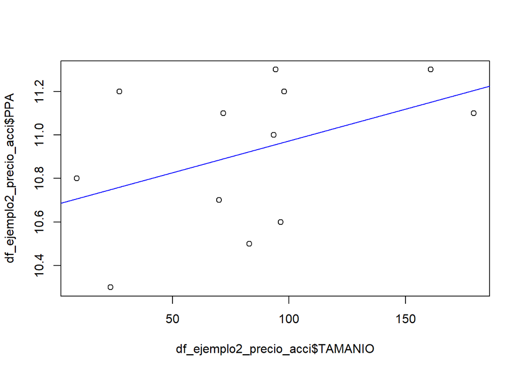

```r
plot(df_ejemplo2_precio_acci$TAMANIO,df_ejemplo2_precio_acci$PPA )
abline(lm_model_precio_acci, col="blue")
```

# Modelo Lineal Multiple

## Roses y la inclusión de una variable en el tiempo

```r
library(readxl)

df_rosas <- read_excel("Regresion_Class_29_August_Modelo_Lineal_Simple_ejemplo_rosas.xls",
                 sheet = "Sheet1")
df_rosas
```

```
## # A tibble: 16 × 6
##     YEAR     Y    X2    X3    X4    X5
##    <dbl> <dbl> <dbl> <dbl> <dbl> <dbl>
##  1 1971. 11484  2.26  3.49  158.     1
##  2 1971.  9348  2.54  2.85  173.     2
##  3 1972.  8429  3.07  4.06  165.     3
##  4 1972. 10079  2.91  3.64  173.     4
##  5 1972.  9240  2.73  3.21  178.     5
##  6 1972.  8862  2.77  3.66  199.     6
##  7 1973.  6216  3.59  3.76  186.     7
##  8 1973.  8253  3.23  3.49  189.     8
##  9 1973.  8038  2.6   3.13  180.     9
## 10 1973.  7476  2.89  3.2   183.    10
## 11 1974.  5911  3.77  3.65  182.    11
## 12 1974.  7950  3.64  3.6   185     12
## 13 1974.  6134  2.82  2.94  184     13
## 14 1974.  5868  2.96  3.12  188.    14
## 15 1975.  3160  4.24  3.58  176.    15
## 16 1975.  5872  3.69  3.53  188     16
```

Quitando la primer columna

```r
df_rosas <-df_rosas[,-1]
df_rosas
```

```
## # A tibble: 16 × 5
##        Y    X2    X3    X4    X5
##    <dbl> <dbl> <dbl> <dbl> <dbl>
##  1 11484  2.26  3.49  158.     1
##  2  9348  2.54  2.85  173.     2
##  3  8429  3.07  4.06  165.     3
##  4 10079  2.91  3.64  173.     4
##  5  9240  2.73  3.21  178.     5
##  6  8862  2.77  3.66  199.     6
##  7  6216  3.59  3.76  186.     7
##  8  8253  3.23  3.49  189.     8
##  9  8038  2.6   3.13  180.     9
## 10  7476  2.89  3.2   183.    10
## 11  5911  3.77  3.65  182.    11
## 12  7950  3.64  3.6   185     12
## 13  6134  2.82  2.94  184     13
## 14  5868  2.96  3.12  188.    14
## 15  3160  4.24  3.58  176.    15
## 16  5872  3.69  3.53  188     16
```

Aplicando el modelo linel multipli a la data de rosas

```r
# Load libraries
library(stats)

# Fit linear model
lm_model_rosas <- lm(Y ~ X2+X3+X4+X5, data = df_rosas)

# View model summary
summary(lm_model_rosas)
```

```
##
## Call:
## lm(formula = Y ~ X2 + X3 + X4 + X5, data = df_rosas)
##
## Residuals:
##      Min       1Q   Median       3Q      Max
## -1095.47  -670.22   -76.67   569.51  1945.14
##
## Coefficients:
##              Estimate Std. Error t value Pr(>|t|)
## (Intercept) 10816.043   5988.348   1.806   0.0983 .
## X2          -2227.704    920.466  -2.420   0.0340 *
## X3           1251.141   1157.021   1.081   0.3027
## X4              6.283     30.622   0.205   0.8412
## X5           -197.400    101.561  -1.944   0.0780 .
## ---
## Signif. codes:  0 '***' 0.001 '**' 0.01 '*' 0.05 '.' 0.1 ' ' 1
##
## Residual standard error: 969.9 on 11 degrees of freedom
## Multiple R-squared:  0.8347, Adjusted R-squared:  0.7746
## F-statistic: 13.89 on 4 and 11 DF,  p-value: 0.0002805
```

```r
# Load libraries
library(stats)

# Fit linear model
lm_model_rosas <- lm(Y ~., data = df_rosas)

# View model summary
summary(lm_model_rosas)
```

```
##
## Call:
## lm(formula = Y ~ ., data = df_rosas)
##
## Residuals:
##      Min       1Q   Median       3Q      Max
## -1095.47  -670.22   -76.67   569.51  1945.14
##
## Coefficients:
##              Estimate Std. Error t value Pr(>|t|)
## (Intercept) 10816.043   5988.348   1.806   0.0983 .
## X2          -2227.704    920.466  -2.420   0.0340 *
## X3           1251.141   1157.021   1.081   0.3027
## X4              6.283     30.622   0.205   0.8412
## X5           -197.400    101.561  -1.944   0.0780 .
## ---
## Signif. codes:  0 '***' 0.001 '**' 0.01 '*' 0.05 '.' 0.1 ' ' 1
##
## Residual standard error: 969.9 on 11 degrees of freedom
## Multiple R-squared:  0.8347, Adjusted R-squared:  0.7746
## F-statistic: 13.89 on 4 and 11 DF,  p-value: 0.0002805
```

Para graficar la Y como variable de X5 como una especie de tendencia

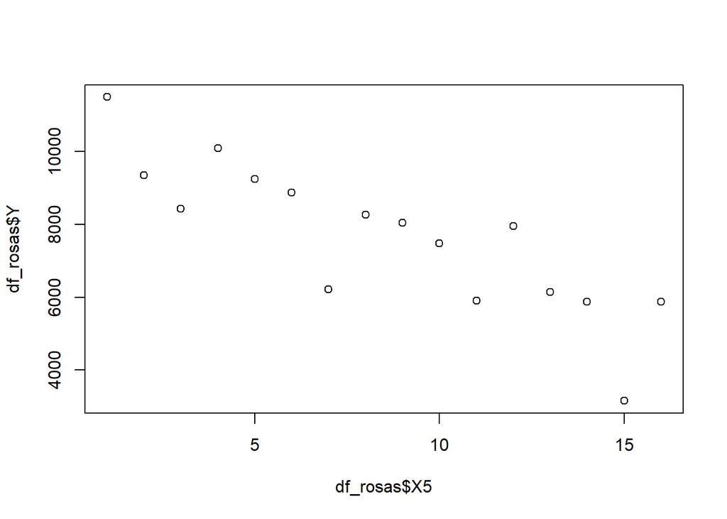

```r
plot(df_rosas$X5, df_rosas$Y)
```

Si solo tomaramos en cuenta a X5 como variable explicativa el valor de X5 es aún más negativo, aunque no considero todas las variables

```r
# Load libraries
library(stats)

# Fit linear model
lm_model_rosas_solo_x5 <- lm(Y ~ X5, data = df_rosas)

# View model summary
summary(lm_model_rosas_solo_x5)
```

```
##
## Call:
## lm(formula = Y ~ X5, data = df_rosas)
##
## Residuals:
##     Min      1Q  Median      3Q     Max
## -2109.4  -709.5   309.6   629.1  1584.2
##
## Coefficients:
##             Estimate Std. Error t value Pr(>|t|)
## (Intercept) 10751.50     580.97  18.506 3.07e-11 ***
## X5           -365.47      60.08  -6.083 2.82e-05 ***
## ---
## Signif. codes:  0 '***' 0.001 '**' 0.01 '*' 0.05 '.' 0.1 ' ' 1
##
## Residual standard error: 1108 on 14 degrees of freedom
## Multiple R-squared:  0.7255, Adjusted R-squared:  0.7059
## F-statistic:    37 on 1 and 14 DF,  p-value: 2.824e-05
```

Para dejar de considerar las variables X3 y X4 como varles independientes

```r
# Fit linear model
lm_model_rosas_signifcativos <- lm(Y ~ X2+X5, data = df_rosas)

# View model summary
summary(lm_model_rosas_signifcativos)
```

```
##
## Call:
## lm(formula = Y ~ X2 + X5, data = df_rosas)
##
## Residuals:
##     Min      1Q  Median      3Q     Max
## -1123.0  -702.1  -106.5   657.9  1999.0
##
## Coefficients:
##             Estimate Std. Error t value Pr(>|t|)
## (Intercept) 14494.09    1559.88   9.292 4.19e-07 ***
## X2          -1509.26     596.73  -2.529  0.02516 *
## X5           -254.12      67.41  -3.770  0.00234 **
## ---
## Signif. codes:  0 '***' 0.001 '**' 0.01 '*' 0.05 '.' 0.1 ' ' 1
##
## Residual standard error: 941.2 on 13 degrees of freedom
## Multiple R-squared:  0.816,  Adjusted R-squared:  0.7877
## F-statistic: 28.83 on 2 and 13 DF,  p-value: 1.663e-05
```

## Ejemplo 1 de VARIABLES dicotomicas

```r
library(readxl)

df_dicotomicas <- read_excel("Regresion_Class_29_August_Modelo_Lineal_Simple_ejemplo1.xls",
                 sheet = "Sheet1")
df_dicotomicas
```

```
## # A tibble: 12 × 6
##        Y    X1    X2    X3    X4    X5
##    <dbl> <dbl> <dbl> <dbl> <dbl> <dbl>
##  1  11.2  56.5  71    38.5  43       1
##  2  14.5  59.5  72.5  38.2  44.8     1
##  3  17.2  69.2  76    42.5  49       0
##  4  17.8  74.5  79.5  43.4  56.3     0
##  5  19.3  81.2  84    47.5  60.2     0
##  6  24.5  88    86.2  47.4  62       1
##  7  21.2  78.2  80.5  44.5  58.1     1
##  8  16.9  69    72    41.8  48.1     1
##  9  14.8  58.1  68    42.1  46       0
## 10  20    80.5  85    48.1  60.3     0
## 11  13.2  58.3  71    37.5  47.1     0
## 12  22.5  84    87.2  51    65.2     0
```

```r
# Fit linear model
lm_model_dicotomica <- lm(Y ~ X1+X2+X3+X4+X5, data = df_dicotomicas)

# View model summary
summary(lm_model_dicotomica)
```

```
##
## Call:
## lm(formula = Y ~ X1 + X2 + X3 + X4 + X5, data = df_dicotomicas)
##
## Residuals:
##     Min      1Q  Median      3Q     Max
## -1.3915 -0.7957  0.2589  0.7573  1.0603
##
## Coefficients:
##             Estimate Std. Error t value Pr(>|t|)
## (Intercept)  0.87922    9.81196   0.090   0.9315
## X1           0.34192    0.15857   2.156   0.0745 .
## X2          -0.30256    0.23412  -1.292   0.2438
## X3           0.09948    0.26588   0.374   0.7211
## X4           0.21159    0.26150   0.809   0.4493
## X5           0.87212    0.93602   0.932   0.3874
## ---
## Signif. codes:  0 '***' 0.001 '**' 0.01 '*' 0.05 '.' 0.1 ' ' 1
##
## Residual standard error: 1.234 on 6 degrees of freedom
## Multiple R-squared:  0.9467, Adjusted R-squared:  0.9023
## F-statistic: 21.32 on 5 and 6 DF,  p-value: 0.0009338
```

PARA ELIMINAR EL INTERCEPTO DEL MODELO LINEAL

```r
# Fit linear model
lm_model_dicotomica_sin_intercepto <- lm(Y ~. +0, data = df_dicotomicas)

# View model summary
summary(lm_model_dicotomica_sin_intercepto)
```

```
##
## Call:
## lm(formula = Y ~ . + 0, data = df_dicotomicas)
##
## Residuals:
##     Min      1Q  Median      3Q     Max
## -1.4020 -0.7601  0.2959  0.7777  1.0532
##
## Coefficients:
##    Estimate Std. Error t value Pr(>|t|)
## X1   0.3347     0.1262   2.651   0.0329 *
## X2  -0.2853     0.1228  -2.323   0.0531 .
## X3   0.1127     0.2048   0.550   0.5992
## X4   0.2016     0.2191   0.920   0.3882
## X5   0.8945     0.8357   1.070   0.3200
## ---
## Signif. codes:  0 '***' 0.001 '**' 0.01 '*' 0.05 '.' 0.1 ' ' 1
##
## Residual standard error: 1.143 on 7 degrees of freedom
## Multiple R-squared:  0.9977, Adjusted R-squared:  0.996
## F-statistic: 604.2 on 5 and 7 DF,  p-value: 4.597e-09
```

```r
# Fit linear model
lm_model_dicotomica2 <- lm(Y ~ X2+X5, data = df_dicotomicas)

# View model summary
summary(lm_model_dicotomica2)
```

```
##
## Call:
## lm(formula = Y ~ X2 + X5, data = df_dicotomicas)
##
## Residuals:
##     Min      1Q  Median      3Q     Max
## -3.5888 -1.1026 -0.1479  1.4437  2.6038
##
## Coefficients:
##              Estimate Std. Error t value Pr(>|t|)
## (Intercept) -23.69384    6.73494  -3.518 0.006535 **
## X2            0.52780    0.08512   6.201 0.000159 ***
## X5            1.00917    1.12869   0.894 0.394549
## ---
## Signif. codes:  0 '***' 0.001 '**' 0.01 '*' 0.05 '.' 0.1 ' ' 1
##
## Residual standard error: 1.9 on 9 degrees of freedom
## Multiple R-squared:  0.8104, Adjusted R-squared:  0.7683
## F-statistic: 19.24 on 2 and 9 DF,  p-value: 0.0005626
```